# Intro OEB R Course, Session 2

Callin Switzer

September 24, 2015

Topics:

1. Set and get working directory
   - Review: import data into R.
   - New: read in different data types
2. Navigate your data frames, using square-bracket and “$” notation.
3. Quickly visualize your data with the plot(), hist(), and rug() functions and/or car::scatterplotMatrix()
4. Manipulate your data (sub setting with logical statements, cleaning data, making calculations with a data frame)
5. Export data
6. Install new libraries
7. Use functions from different libraries
8. ** Formatting data for visualization
9. ** Loops and apply functions()

**if time

Note: We’re skipping string manipulation

```
## [1] "Last knit to html at:  2015-09-24 11:48:48"
```

# Review

#### What we learned last time:

1. “#” is the comment character
2. <- or = will assign things to variables
3. R has different data types – character, logical, numeric, factor
4. R has different data structures – arrays, matrices, lists, vectors, data frames
5. Some handy functions include str(), summary(), length(), nrow(), ncol(), names(), colnames(), class(), mode().
6. You can import data using the read.csv() function, and if you want the file path, you can use the file.choose() function.

```r
## Here is some of my unpublished data -- if you publish it, please include me as an author!
## but seriously, please don't share.
# flowerFile <- file.choose()

flowerFile <- "/Users/callinswitzer/Dropbox/Harvard/RByCall/RClassMaterials/Session2/DataSets/CallinPollen.csv"

flr <- read.csv(flowerFile)
flr[ 1:5 , 1:4] # shows the first 5 rows, first 4 columns
```

```
##   flowerNum     trt daysOpen distance
## 1        14 Ambient        4        3
## 2        14 Ambient        4        3
## 3        15 Ambient        3        4
## 4        15 Ambient        3        4
## 5        16 Ambient        2        4
```

# New Material

## 1. Set and get your working directory

Session -> Set Working Directory -> Choose Directory

```r
# gets your working directory
getwd()
```

```
## [1] "/Users/callinswitzer/Dropbox/Harvard/RByCall/rclassmaterials/Session2"
```

```r
# sets your working directory
setwd("/Users/callinswitzer/Dropbox/Harvard/rbycall/RClassMaterials/Session2")
```

#### Handy functions

- dir() # prints stuff in your working directory
- file.show() # allows you to open files

## Importing data into R

You can click “Import Dataset”, or write the code yourself

```r
# read.table is another (possibly more flexible) way to read in data

# get names of files in datasets folder
dir("datasets")
```

```
## [1] "arrests.txt"      "CallinPollen.csv" "loblolly.txt"
## [4] "mtcars.txt"       "spray-easy.txt"   "spray.txt"
## [7] "toothGrowth.txt"  "yarn.txt"
```

```r
# view the file
file.show("datasets/mtcars.txt")

# read in space-separated file
crs <- read.table("datasets/mtcars.txt", sep = " ")
head(crs)
```

```
##                    mpg cyl disp  hp drat    wt  qsec vs am gear carb
## Mazda RX4         21.0   6  160 110 3.90 2.620 16.46  0  1    4    4
## Mazda RX4 Wag     21.0   6  160 110 3.90 2.875 17.02  0  1    4    4
## Datsun 710        22.8   4  108  93 3.85 2.320 18.61  1  1    4    1
## Hornet 4 Drive    21.4   6  258 110 3.08 3.215 19.44  1  0    3    1
## Hornet Sportabout 18.7   8  360 175 3.15 3.440 17.02  0  0    3    2
## Valiant           18.1   6  225 105 2.76 3.460 20.22  1  0    3    1
```

```r
## you can also import directly from a web URL
# this is a dataset about rats from crawley book
URL <- "http://nature.berkeley.edu/~casterln/crawley/rats.txt"
rats <- read.csv(URL)
head(rats) # not quite right
```

```
##   Glycogen.Treatment.Rat.Liver
## 1                 131\t1\t1\t1
## 2                 130\t1\t1\t1
## 3                 131\t1\t1\t2
## 4                 125\t1\t1\t2
## 5                 136\t1\t1\t3
## 6                 142\t1\t1\t3
```

```r
rats <- read.csv(URL, sep = "\t")
head(rats)
```

```
##   Glycogen Treatment Rat Liver
## 1      131         1   1     1
## 2      130         1   1     1
## 3      131         1   1     2
## 4      125         1   1     2
## 5      136         1   1     3
## 6      142         1   1     3
```

# Exercises(1):

### 1.1. Figure out what type of separator is used in the “mtcars.txt” dataset, using the file.show() function.

### 1.2. Import the dataset, “mtcars.txt”, using either the read.csv() function or the read.table() function. Call the dataset, “crs”.

### 1.3. Look at the first few rows of the dataset, “crs”, to make sure you read it in correctly.

### 1.4 *Advanced* Read in spray.txt dataset. Try to make it look like the spray-easy.txt dataset.

## 2. Navigate your data, using “square bracket” notation and “$” notation.

```r
# read in data (again)
flr <- read.csv("datasets/CallinPollen.csv")

summary(flr)
```

```
##    flowerNum                                 trt         daysOpen
##  Min.   : 14.00   Ambient                      :198   Min.   :1.000
##  1st Qu.: 71.25   dehumidifier                 : 45   1st Qu.:2.000
##  Median :200.50   AC                           : 39   Median :2.000
##  Mean   :178.89   heat set to 80F overnight    : 36   Mean   :2.115
##  3rd Qu.:275.75   heat and humidifier in alcove: 32   3rd Qu.:2.000
##  Max.   :332.00   Humidifier                   : 32   Max.   :4.000
##                   (Other)                      : 60
##     distance       shakeNumber         temp          humidity
##  Min.   : 1.000   Min.   :1.000   Min.   :17.80   Min.   :35.00
##  1st Qu.: 2.000   1st Qu.:1.000   1st Qu.:23.80   1st Qu.:50.00
##  Median : 4.000   Median :1.000   Median :24.90   Median :55.00
##  Mean   : 4.727   Mean   :2.419   Mean   :25.31   Mean   :55.58
##  3rd Qu.: 7.000   3rd Qu.:2.000   3rd Qu.:27.93   3rd Qu.:62.00
##  Max.   :12.000   Max.   :8.000   Max.   :33.80   Max.   :83.00
##  NA's   :321
##                     notes     dropFromAnalysis
##                        :170    :423
##  petals forward        : 21   y: 19
##  brown anthers         :  6
##  clipped plant way back:  4
##  unhealthy plant       :  4
##  (Other)               : 30
##  NA's                  :207
##                      file     pxToMmConversion  firstPollen
##  014_A_4_03_01 06152014:  1   Min.   :31.80    Min.   :  1.0
##  014_A_4_03_02 06152014:  1   1st Qu.:33.06    1st Qu.: 96.0
##  015_A_3_04_01 06152014:  1   Median :33.53    Median :166.0
##  015_A_3_04_02 06152014:  1   Mean   :33.79    Mean   :192.4
##  016_A_2_04_01 06152014:  1   3rd Qu.:34.73    3rd Qu.:262.5
##  016_A_2_04_02 06152014:  1   Max.   :36.18    Max.   :704.0
##  (Other)               :436
##  firstPollenOutOfScreen  blankFrames         slope
##  Min.   : 59.0          Min.   : 145.0   Min.   :0.000000
##  1st Qu.:162.0          1st Qu.: 340.5   1st Qu.:0.001875
##  Median :280.5          Median : 587.0   Median :0.005561
##  Mean   :294.0          Mean   : 557.5   Mean   :0.008980
##  3rd Qu.:377.5          3rd Qu.: 704.2   3rd Qu.:0.011870
##  Max.   :908.0          Max.   :1211.0   Max.   :0.132516
##
```

[output cut: 9 more lines]

```
##  "1/1000":121   Min.   :0.38   Min.   :279   Min.   :0.1792   big002:383
##  "1/1500":295   1st Qu.:0.38   1st Qu.:279   1st Qu.:0.1792   sml001: 59
##  "1/2000": 26   Median :0.38   Median :279   Median :0.1792
##                 Mean   :0.38   Mean   :279   Mean   :0.1792
##                 3rd Qu.:0.38   3rd Qu.:279   3rd Qu.:0.1792
##                 Max.   :0.38   Max.   :279   Max.   :0.1792
##
##                    openTime     DateOfExp
##  after 3pm previous day:234          :147
##  afternoon             : 13   8/6/14 : 36
##  midday                :  4   7/30/14: 34
##  morning               :  9   8/2/14 : 32
##  morningBeforeTrial    :  9   6/25/14: 31
##  overnight             : 12   8/1/14 : 28
##  NA's                  :161   (Other):134
```

```r
fr.df <- flr["frameRate"] # this returns a data frame, which we often don't want
head(fr.df)
```

```
##   frameRate
## 1       500
## 2       500
## 3       500
## 4       500
## 5       500
## 6       500
```

```r
class(fr.df)
```

```
## [1] "data.frame"
```

```r
fr.vec <- flr[["frameRate"]] # this gives a vector
fr.vec2 <- flr$frameRate # gives a vector
head(fr.vec)
```

```
## [1] 500 500 500 500 500 500
```

```r
head(fr.vec2)
```

```
## [1] 500 500 500 500 500 500
```

```r
class(fr.vec)
```

```
## [1] "integer"
```

```r
# if you want a new data frame with a subset of columns
smDF <- flr[c("frameRate", "flowerNum")]
head(smDF)
```

```
##   frameRate flowerNum
## 1       500        14
## 2       500        14
## 3       500        15
## 4       500        15
## 5       500        16
## 6       500        16
```

```r
# another possible way
smDF <- flr[, c("frameRate", "flowerNum")] # [rows, columns]
head(smDF)
```

```
##   frameRate flowerNum
## 1       500        14
## 2       500        14
## 3       500        15
## 4       500        15
## 5       500        16
## 6       500        16
```

```r
# another way
smDF <- flr[, c(19,1)] # getting all rows, columns 19 and 1
head(smDF)
```

```
##   frameRate flowerNum
## 1       500        14
## 2       500        14
## 3       500        15
## 4       500        15
## 5       500        16
## 6       500        16
```

# Exercises(2):

### 2.1. Read in the dataset, “toothGrowth.txt”; call it “tooth”. Use read.table(…, header = TRUE)

### 2.2. Make a new dataframe, with only the columns “len”, and “supp” from the tooth dataframe. Call the new dataframe, “tooth.sm”. Print the first few rows of the data frame to check your work.

### 2.3. Make a new vector, called “dose.vec” that contains the “dose” column from the tooth dataset. Print the first few items in the vector to check your work.

## 3. Quickly visualize your data (using car::scatterplotMatrix() and plot())

#### plot()

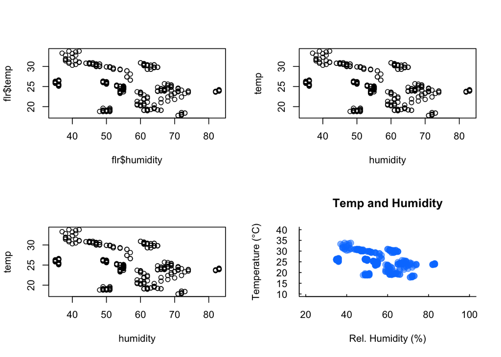

```r
# we can use the base plot() function
?plot # gets help about the plot function
# we're using the flr dataset

# different ways to plot
par(mfrow = c(2,2)) # tells R to put  2 X 2 plots per panel
plot(x = flr$humidity, y=flr$temp)
plot(temp~humidity, data = flr)
with(flr, plot(y = temp, x = humidity))
with(flr, plot(y = temp, x = humidity,
               main = "Temp and Humidity", # title
               ylab = expression(paste("Temperature (",degree,"C)")), # y label
               xlab = "Rel. Humidity (%)" , # x label
               bty = "l", # type of box around the plot
               pch = 20, # what symbol to plot: "point change"?
               col = rgb(0,0.5,1, 0.5), # color of the poings, and transparency
               cex = 2, # size of points
               tck = .03, # length of ticks
               las = 1, # axis label direction
               ylim = c(10, 40), # y limits
               xlim = c(20, 100) # x limits
               ))
```

```r
par(mfrow = c(1,1)) # reset the plots per panel

# ?par will show you all of the parameters you can adjust
# can also use dev.off() to clear the plotting device
```

#### hist() and rug()

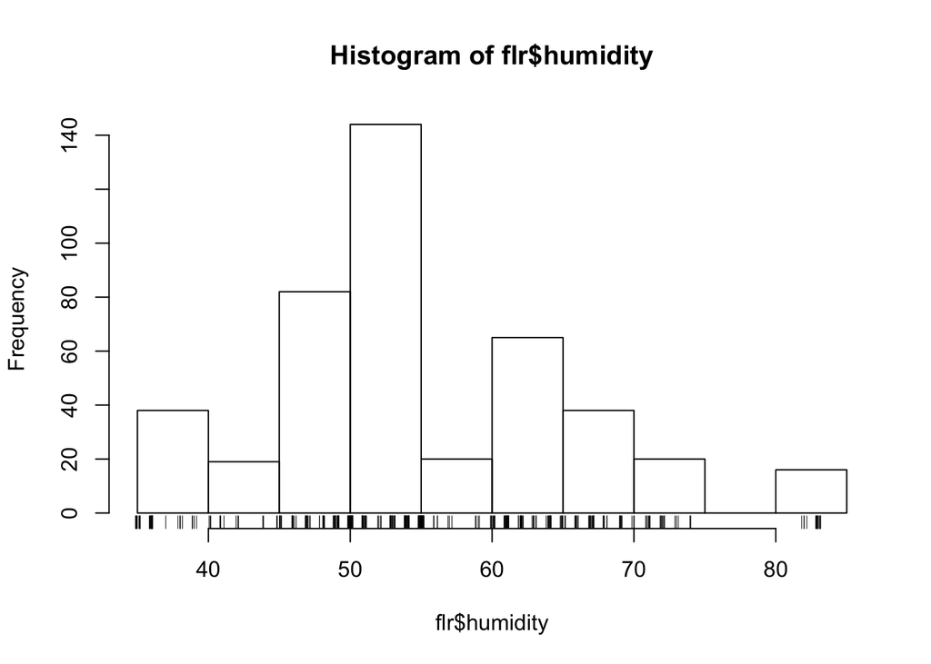

```r
# histograms help us look at distributions and check for outliers
hist(flr$humidity, breaks = 15)
rug(jitter(flr$humidity)) # jitter() helps you see overlapping points
```

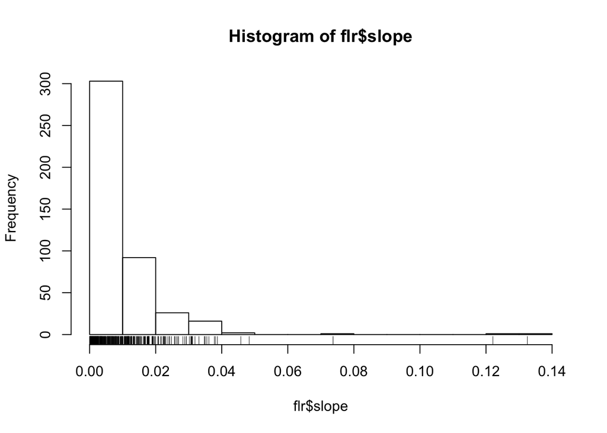

```r
hist(flr$slope); rug(flr$slope)
```

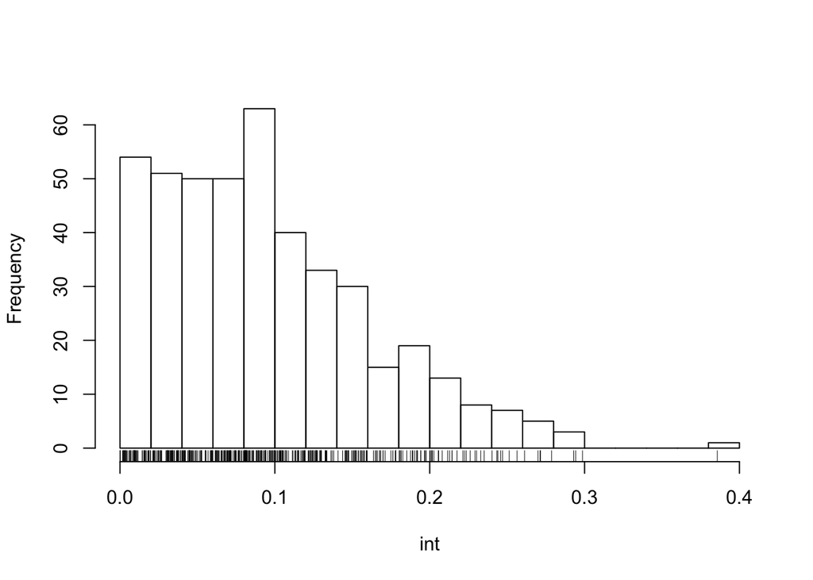

```r
# a look ahead
histRug <- function(vec, ...){
     hist(vec, ...)
     rug(vec)
}

histRug(flr$int, breaks = 15, xlab = "int", main = NULL)
```

#### Scatterplot matrix

```r
# look at scatterplot matrix of numeric data to view "marginal relationships"
colnames(flr) # figure out which columns I want
```

```
##  [1] "flowerNum"              "trt"
##  [3] "daysOpen"               "distance"
##  [5] "shakeNumber"            "temp"
##  [7] "humidity"               "notes"
##  [9] "dropFromAnalysis"       "file"
## [11] "pxToMmConversion"       "firstPollen"
## [13] "firstPollenOutOfScreen" "blankFrames"
## [15] "slope"                  "int"
## [17] "aperture"               "focus"
## [19] "frameRate"              "shutter"
## [21] "amplitude"              "freq"
## [23] "sec"                    "plant"
## [25] "openTime"               "DateOfExp"
```

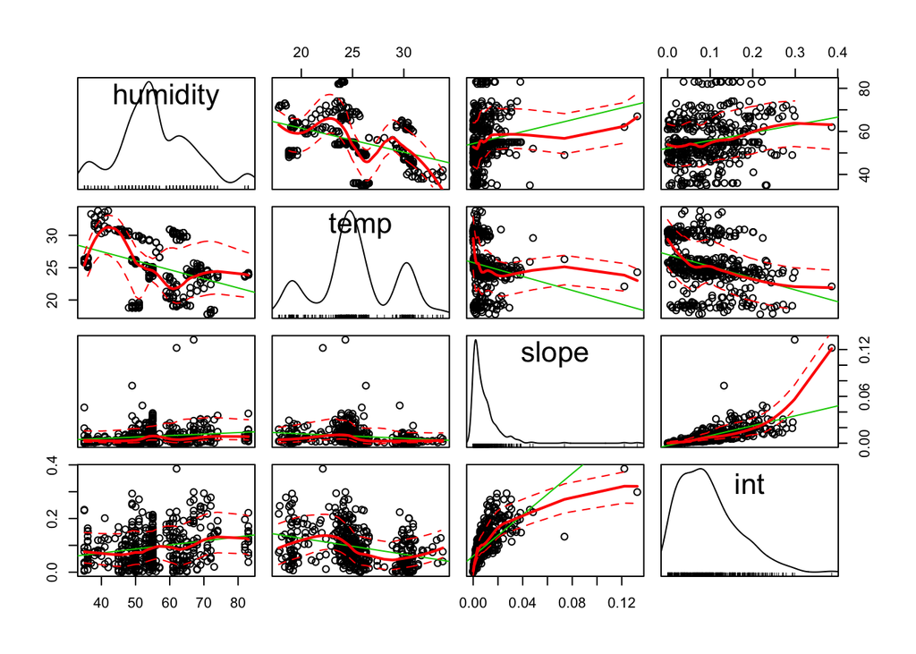

```r
#install.packages("car")
car::scatterplotMatrix(flr[c("humidity", "temp", "slope", "int")])
```

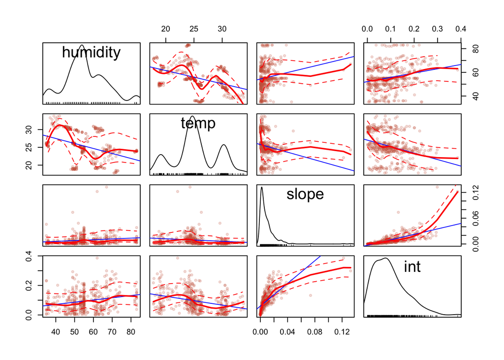

```r
# change the paramters for the scatterplots
car::scatterplotMatrix(flr[c("humidity", "temp", "slope", "int")],
                       pch = 20,
                       col = c("blue", "red", rgb(.8,0.4, .3, 0.2)))
```

```r
# Another way:
# library(car)
# scatterplotMatrix(flr[c("humidity", "temp", "slope", "int")])
```

# Exercises(3):

### 3.1. Read in the “arrests.txt” data frame. Call it “arrests”. Make a histogram of the “UrbanPop” column. Draw a rug underneath the histogram

### 3.2. Draw a scatterplotMatrix of the arrests dataset.

### 3.3. Read in the “mtcars.txt” file; call it crs (if you haven’t already). Plot y = mpg, x = wt.

### 3.4. *Advanced* Figure out how to make a boxplot of y = mpg, x = cyl. Hint: make cyl into a factor, or use the boxplot() function.

### 3.5. *Advanced* Figure out how to color the poins in the scatterplot (y = mpg, x = cyl) by their number of cylinders. Also, change the points into triangles (hint: ?pch)

### 3.6. *Advanced* Figure out how to add a legend to your plot.

## 4. Manipulate your data (sub setting with logical statements, cleaning data, making calculations with a data frame)

#### List of logical operators

- “==” equals
- “!=” not equal
- “&” and
- “|” or
- “>” greather
- “<” less
- “>=” greather or equal
- “<=” less or equal

```r
# select rows, all columns
FewRows <- flr[10:20, ]
FewRows
```

```
##    flowerNum     trt daysOpen distance shakeNumber temp humidity
## 10        19 Ambient        3        4           1 23.8       54
## 11        19 Ambient        3        4           2 23.8       54
## 12        20 Ambient        4        6           1 23.8       54
## 13        20 Ambient        4        6           2 23.8       54
## 14        21 Ambient        1        1           1 23.7       55
## 15        21 Ambient        1        1           2 23.7       55
## 16        22 Ambient        1        7           1 24.1       55
## 17        22 Ambient        1        7           2 24.1       55
## 18        23 Ambient        3        1           1 24.2       55
## 19        23 Ambient        3        1           2 24.2       55
## 20        24 Ambient        3        1           1 24.3       55
##             notes dropFromAnalysis                   file pxToMmConversion
## 10           <NA>                  019_A_3_04_01 06152014         33.71517
## 11           <NA>                  019_A_3_04_02 06152014         33.61158
```

[output cut: 45 more lines]

```r
# use logical statements to return logical vectors
amb <- flr$trt == "Ambient" # returns a logical vector that is TRUE when flr$trt is ambient
head(amb)
```

```
## [1] TRUE TRUE TRUE TRUE TRUE TRUE
```

```r
summary(amb)
```

```
##    Mode   FALSE    TRUE    NA's
## logical     244     198       0
```

```r
# Use "&" to refine
ambHighHum <- flr$trt == "Ambient" & flr$humidity > 50
summary(ambHighHum)
```

```
##    Mode   FALSE    TRUE    NA's
## logical     278     164       0
```

```r
# Note: can't use x == NA; us is.na() instead
head(flr$openTime == NA) # doesn't work
```

```
## [1] NA NA NA NA NA NA
```

```r
naOpen <- is.na(flr$openTime)
naOpen
```

```
##   [1]  TRUE  TRUE  TRUE  TRUE  TRUE  TRUE  TRUE  TRUE  TRUE  TRUE  TRUE
##  [12]  TRUE  TRUE  TRUE  TRUE  TRUE  TRUE  TRUE  TRUE  TRUE  TRUE  TRUE
##  [23]  TRUE  TRUE  TRUE  TRUE  TRUE  TRUE  TRUE  TRUE  TRUE  TRUE  TRUE
##  [34]  TRUE  TRUE  TRUE  TRUE  TRUE  TRUE  TRUE  TRUE  TRUE  TRUE  TRUE
##  [45]  TRUE  TRUE  TRUE  TRUE  TRUE  TRUE  TRUE  TRUE  TRUE  TRUE  TRUE
##  [56]  TRUE  TRUE  TRUE  TRUE  TRUE  TRUE  TRUE  TRUE  TRUE  TRUE  TRUE
##  [67]  TRUE  TRUE  TRUE  TRUE  TRUE  TRUE  TRUE  TRUE  TRUE  TRUE  TRUE
##  [78]  TRUE  TRUE  TRUE  TRUE  TRUE  TRUE  TRUE  TRUE  TRUE  TRUE  TRUE
##  [89]  TRUE  TRUE  TRUE  TRUE  TRUE  TRUE  TRUE  TRUE  TRUE  TRUE  TRUE
## [100]  TRUE  TRUE  TRUE  TRUE  TRUE  TRUE  TRUE  TRUE  TRUE  TRUE  TRUE
## [111]  TRUE  TRUE  TRUE  TRUE  TRUE  TRUE  TRUE  TRUE  TRUE  TRUE  TRUE
## [122]  TRUE  TRUE  TRUE  TRUE  TRUE  TRUE  TRUE  TRUE  TRUE  TRUE  TRUE
## [133]  TRUE  TRUE  TRUE  TRUE  TRUE  TRUE  TRUE  TRUE  TRUE  TRUE  TRUE
## [144]  TRUE  TRUE  TRUE  TRUE  TRUE  TRUE  TRUE  TRUE  TRUE  TRUE  TRUE
## [155]  TRUE  TRUE  TRUE  TRUE  TRUE  TRUE  TRUE FALSE FALSE FALSE FALSE
```

[output cut: 26 more lines]

#### we can use logical statements to subset dataframes and clean data

Use square bracket notation

```r
# select rows where daysOpen == 1, all columns
d1 <- flr[flr$daysOpen == 1, ]
summary(d1)
```

```
##    flowerNum                         trt        daysOpen    distance
##  Min.   : 17.0   Ambient               :46   Min.   :1   Min.   : 1.000
##  1st Qu.: 34.0   Humidifier            : 2   1st Qu.:1   1st Qu.: 2.000
##  Median : 46.0   AC                    : 1   Median :1   Median : 5.000
##  Mean   : 64.9   AC and dehumidifier   : 0   Mean   :1   Mean   : 4.641
##  3rd Qu.: 73.0   AC set to 62 overnight: 0   3rd Qu.:1   3rd Qu.: 7.000
##  Max.   :163.0   dehumidifier          : 0   Max.   :1   Max.   :10.000
##                  (Other)               : 0               NA's   :10
##   shakeNumber         temp          humidity
##  Min.   :1.000   Min.   :18.80   Min.   :50.0
##  1st Qu.:1.000   1st Qu.:24.10   1st Qu.:53.0
##  Median :1.000   Median :24.50   Median :55.0
##  Mean   :1.408   Mean   :24.39   Mean   :58.9
##  3rd Qu.:2.000   3rd Qu.:24.90   3rd Qu.:55.0
##  Max.   :2.000   Max.   :25.30   Max.   :83.0
##
##                              notes    dropFromAnalysis
##  petals forward                 : 4    :47
##  two petals stuck together      : 2   y: 2
##  Anther deformed                : 1
##  Anther not fit snugly in shaker: 1
##  Open on same day as experiments: 1
##  (Other)                        : 0
##  NA's                           :40
##                      file    pxToMmConversion  firstPollen
##  017_A_1_01_02 06152014: 1   Min.   :32.16    Min.   :  1.0
##  021_A_1_01_01 06152014: 1   1st Qu.:33.23    1st Qu.: 63.0
##  021_A_1_01_02 06152014: 1   Median :33.38    Median : 90.0
##  022_A_1_07_01 06152014: 1   Mean   :33.37    Mean   :105.9
##  022_A_1_07_02 06152014: 1   3rd Qu.:33.63    3rd Qu.:123.0
##  025_A_1_02_01 06152014: 1   Max.   :33.89    Max.   :438.0
##  (Other)               :43
##  firstPollenOutOfScreen  blankFrames        slope
##  Min.   : 66.0          Min.   :181.0   Min.   :0.0009956
##  1st Qu.:105.0          1st Qu.:261.0   1st Qu.:0.0085708
##  Median :138.0          Median :291.0   Median :0.0118328
##  Mean   :158.6          Mean   :345.6   Mean   :0.0143197
##  3rd Qu.:175.0          3rd Qu.:334.0   3rd Qu.:0.0180549
##  Max.   :517.0          Max.   :922.0   Max.   :0.0386782
##
```

[output cut: 9 more lines]

```
##  Min.   :0.38   Min.   :279   Min.   :0.1792   big002:49
##  1st Qu.:0.38   1st Qu.:279   1st Qu.:0.1792   sml001: 0
##  Median :0.38   Median :279   Median :0.1792
##  Mean   :0.38   Mean   :279   Mean   :0.1792
##  3rd Qu.:0.38   3rd Qu.:279   3rd Qu.:0.1792
##  Max.   :0.38   Max.   :279   Max.   :0.1792
##
##                    openTime    DateOfExp
##  after 3pm previous day: 0          :40
##  afternoon             : 0   6/26/14: 7
##  midday                : 0   6/24/14: 2
##  morning               : 0   6/25/14: 0
##  morningBeforeTrial    : 0   7/2/14 : 0
##  overnight             : 7   7/22/14: 0
##  NA's                  :42   (Other): 0
```

```r
# select rows where daysOpen does not = 1, and distance == 1
d1d1 <- flr[flr$daysOpen != 1 & flr$distance == 1, ]
head(d1d1)
```

```
##    flowerNum     trt daysOpen distance shakeNumber temp humidity
## 18        23 Ambient        3        1           1 24.2       55
## 19        23 Ambient        3        1           2 24.2       55
## 20        24 Ambient        3        1           1 24.3       55
## 21        24 Ambient        3        1           2 24.3       55
## 24        26 Ambient        2        1           1 24.4       55
## 25        26 Ambient        2        1           2 24.4       55
##             notes dropFromAnalysis                   file pxToMmConversion
## 18 petals forward                  023_A_3_01_01 06152014         33.53424
## 19 petals forward                  023_A_3_01_02 06152014         33.44562
## 20           <NA>                  024_A_3_01_01 06152014         33.27383
## 21           <NA>                  024_A_3_01_02 06152014         33.31807
## 24 petals forward                  026_A_2_01_01 06152014         33.60898
## 25 petals forward                  026_A_2_01_02 06152014         33.65996
##    firstPollen firstPollenOutOfScreen blankFrames       slope       int
```

[output cut: 20 more lines]

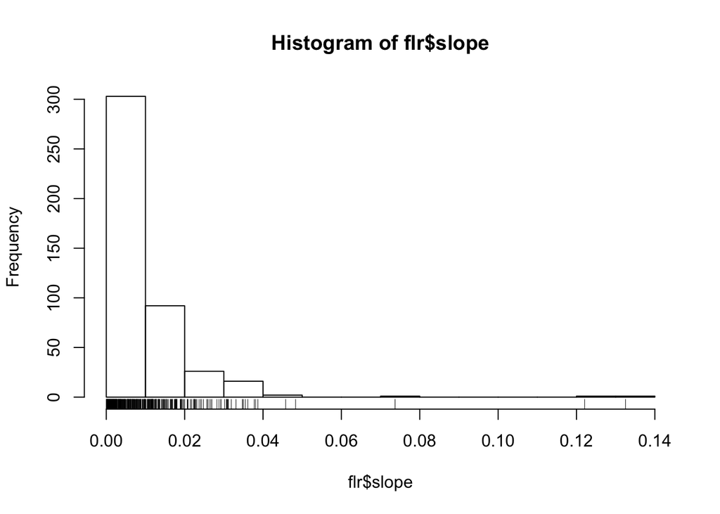

```r
# cleaning data
hist(flr$slope); rug(flr$slope)
```

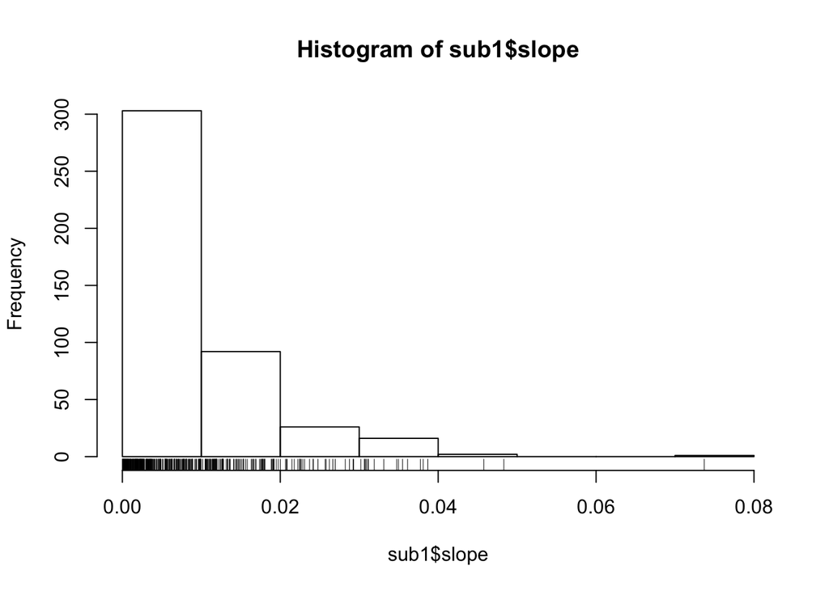

```r
# say we want to drop the points where slope > 0.12
sub1 <- flr[flr$slope < 0.12, ]
hist(sub1$slope); rug(sub1$slope)
```

#### Calculations within data frames

And tabulating some data from the data frames

```r
# say we want to calculate a new measurement that is a combination of slope + int
flr$NewStat <- flr$slope + flr$int
head(flr$NewStat)
```

```
## [1] 0.04545815 0.08858106 0.10037509 0.14428318 0.23411393 0.18618767
```

```r
# or this will work
flr$NewStat1 <- with(flr, slope + int)
head(flr$NewStat1)
```

```
## [1] 0.04545815 0.08858106 0.10037509 0.14428318 0.23411393 0.18618767
```

```r
# say we want to change one of the variable types in our data frame
class(flr$daysOpen)
```

```
## [1] "integer"
```

```r
flr$daysOpen <- as.factor(flr$daysOpen)
class(flr$daysOpen)
```

```
## [1] "factor"
```

```r
# or this will work
class(flr$flowerNum)
```

```
## [1] "integer"
```

```r
flr <- within(flr, flowerNum <- as.factor(flowerNum))
class(flr$flowerNum)
```

```
## [1] "factor"
```

```r
# calculate averages by individual
# say we want average glycogen for each individual
# URL <- "http://nature.berkeley.edu/~casterln/crawley/rats.txt"
# rats <- read.csv(URL)
# rats <- read.csv(URL, sep = "\t")
summary(rats)
```

```
##     Glycogen       Treatment      Rat          Liver
##  Min.   :125.0   Min.   :1   Min.   :1.0   Min.   :1
##  1st Qu.:135.8   1st Qu.:1   1st Qu.:1.0   1st Qu.:1
##  Median :141.0   Median :2   Median :1.5   Median :2
##  Mean   :142.2   Mean   :2   Mean   :1.5   Mean   :2
##  3rd Qu.:150.0   3rd Qu.:3   3rd Qu.:2.0   3rd Qu.:3
##  Max.   :162.0   Max.   :3   Max.   :2.0   Max.   :3
```

```r
tapply(X = rats$Glycogen, FUN = mean, INDEX = rats$Rat)
```

```
##        1        2
## 138.8333 145.6111
```

```r
# calcuate mean by treatment and individual
tapply(X = c(rats$Glycogen), FUN = mean, INDEX = interaction(rats$Rat, rats$Treatment))
```

```
##      1.1      2.1      1.2      2.2      1.3      2.3
## 132.5000 148.5000 149.6667 152.3333 134.3333 136.0000
```

```r
tab1 <- tapply(X = flr$slope, INDEX = flr$trt, FUN = mean)
class(tab1)
```

```
## [1] "array"
```

```r
mode(tab1)
```

```
## [1] "numeric"
```

```r
# tabulate your data (get counts)
xt1 <- xtabs(formula = ~trt, data = flr)
xt1
```

```
## trt
##                            AC           AC and dehumidifier
##                            39                            22
##        AC set to 62 overnight                       Ambient
##                            10                           198
##                  dehumidifier           heat and humidifier
##                            45                            28
## heat and humidifier in alcove     heat set to 80F overnight
##                            32                            36
##                    Humidifier
##                            32
```

```r
# convert to data frame for easy saving
tab1 <- as.data.frame(tab1)
```

# Exercises(4):

### 4.1 Read in the “loblolly.txt” data. Call it “lob”.

### 4.2 Make a new smaller dataframe, called lob.sm, where “Seed” is not “311”, and where “height” is greater than 5. Plot a histogram of “height” to prove that there are none less than 5 (feel free to add a rug).

```
 * check to see if 311 is in your new dataframe with this command: "311 %in% lob.sm$Seed"
```

### 4.3 Read in the “yarn.txt” file; call it yarn. Make two separate histograms – one for the breaks in wool A and one for the breaks in wool B.

```
 * Advanced plot the histograms side-by-side on one panel, and make sure the x-axis limits are the same for each.
```

### 4.4 *Advanced* Calculate the mean, median, and range for “breaks” for each type of wool in the dataset.

## 5. Export data

```r
# Write text files
# can also use write.csv()
write.table(x = tab1, file = "Tab1.csv", sep = ",",  col.names = FALSE)

# saving plots
pdf(file = "plot1.pdf", width = 5, height = 4) # open graphics device
# can also use postscript()
plot(x = flr$humidity, y=flr$temp) # make your plot
dev.off() # close the graphics device
```

```r
# or just export with the "Export" button
```

# Exercises(5):

### 5.1 Read int the CallinPollen.txt file (if you haven’t already), and call it flr. Plot x = humidity, y = int. Export this plot to a file called “humInt.pdf”. Make the width = 4 and height = 3.

### 5.2 *Advanced* Make that plot look nicer! Change the points to solid dots. Remove the box around the plot. Give it a nice title and rename the axes. Save it with width = 5, height = 4 as “fancyHumInt.pdf”. Note: “int”" is a measurement of pollen released from a flower.

### 5.3 Subset the flr dataset to contain only rows where “distance” > 9 & the “distance” variable is not an “NA” (hint: use !is.na()). Call the new data frame flr.dist. Export this small data frame as “flrDist.csv”.

## 6 - 7 Install new libraries and using functions

use install.packages(“…”), but you only ned to use this the first time you use the library. After that, you can just use library(“…”)

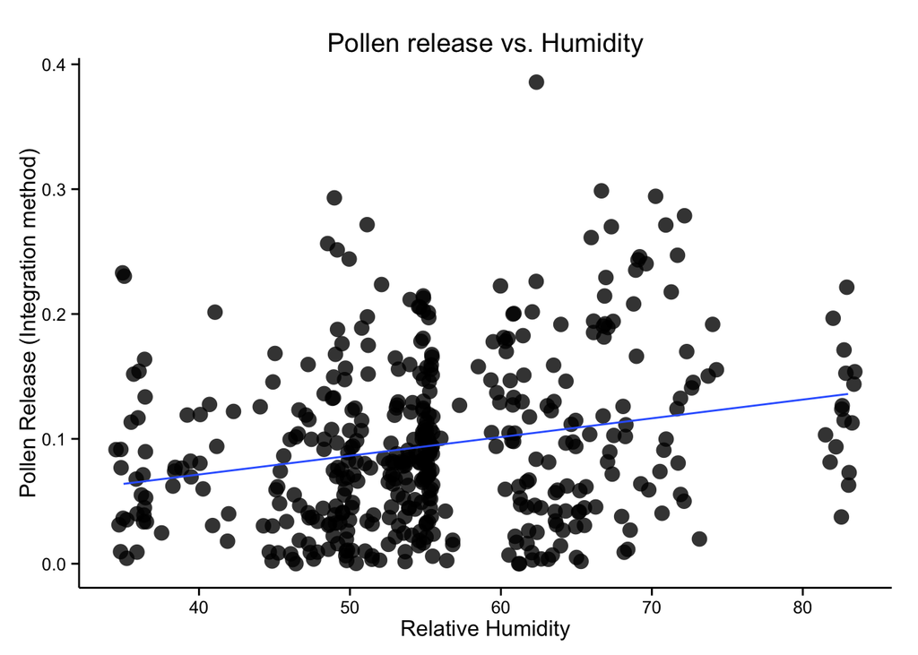

```r
# we def. want ggplot2
# install.packages("ggplot2") # do this only the first time you use a library
library(ggplot2) # now, this package is ready to use
# you can use any function from this library now, without using the :: notation
# help(package = "ggplot2") # gets help for this new package or library
# note: I use package/library interchangeably -- there's probably a difference, but I don't know it.

# let's try it
ggplot(flr, aes(x= humidity, y = int)) +
     geom_point(alpha = 0.8, size = 4, position = position_jitter(width = 0.5, height = 0)) +
     theme_bw() +
     theme(    panel.grid.major = element_blank(),
               panel.grid.minor = element_blank(),
               panel.border = element_blank(),
               panel.background = element_blank(),
               axis.line = element_line(colour = "black")) +
     labs(x = "Relative Humidity", y = "Pollen Release (Integration method)",
          title = 'Pollen release vs. Humidity') +
     geom_smooth(method = "lm", se = FALSE) # add a line without standard error
```

# Exercises(6):

### 6.1 Install and load the package, “plyr”. Run the following code to see if it worked:

ddply(flr, “shakeNumber”, summarise, mean.Int = mean(int)) You should get this:

shakeNumber mean.Int 1 1 0.11814448 2 2 0.08530651 3 7 0.02955185 4 8 0.03822761

### Extra Exercises:

### 6.2 Install the package, “ggmap”

### 6.3 Use the get_map() function and the argument, location = c( lon = -71.114573, lat = 42.379036), to get a map, centered on HUH (hint: get_map(location = c( lon = -71.114573, lat = 42.379036), zoom = 19, maptype = “satellite”))

### 6.4 plot a map of using ggmap()

## Formatting data for visualization

```r
df1 <- data.frame(person = c("bob", "sue", "jack", "ann"), number1 = c(4,5,6,1), number2 = c(2,4,6,6))
df1
```

```
##   person number1 number2
## 1    bob       4       2
## 2    sue       5       4
## 3   jack       6       6
## 4    ann       1       6
```

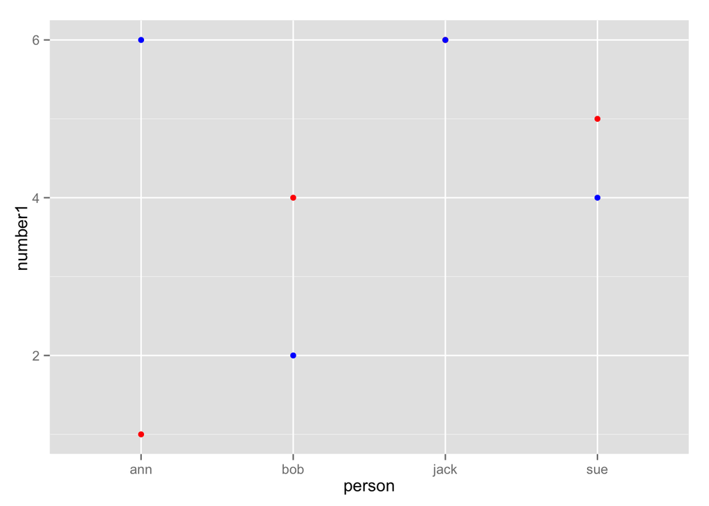

```r
# we want to plot persons' number1 and number2, but we'd need them to be in the same column
# wrong
ggplot(df1) +
     geom_point(aes(x = person, y = number1), color = "red") +
     geom_point(aes(x = person, y = number2), color = "blue")
```

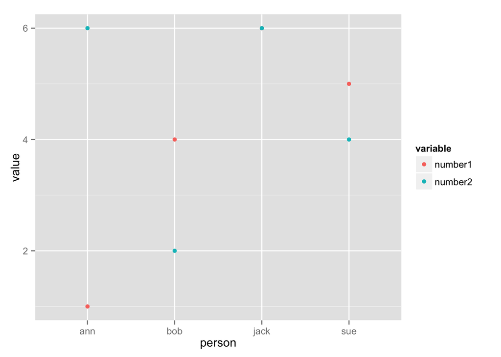

```r
# you can reformat
library(reshape2)
df.melt <- melt(df1, id.vars = "person")

ggplot(df.melt, aes(x = person, y = value)) +
     geom_point(aes(color = variable))
```

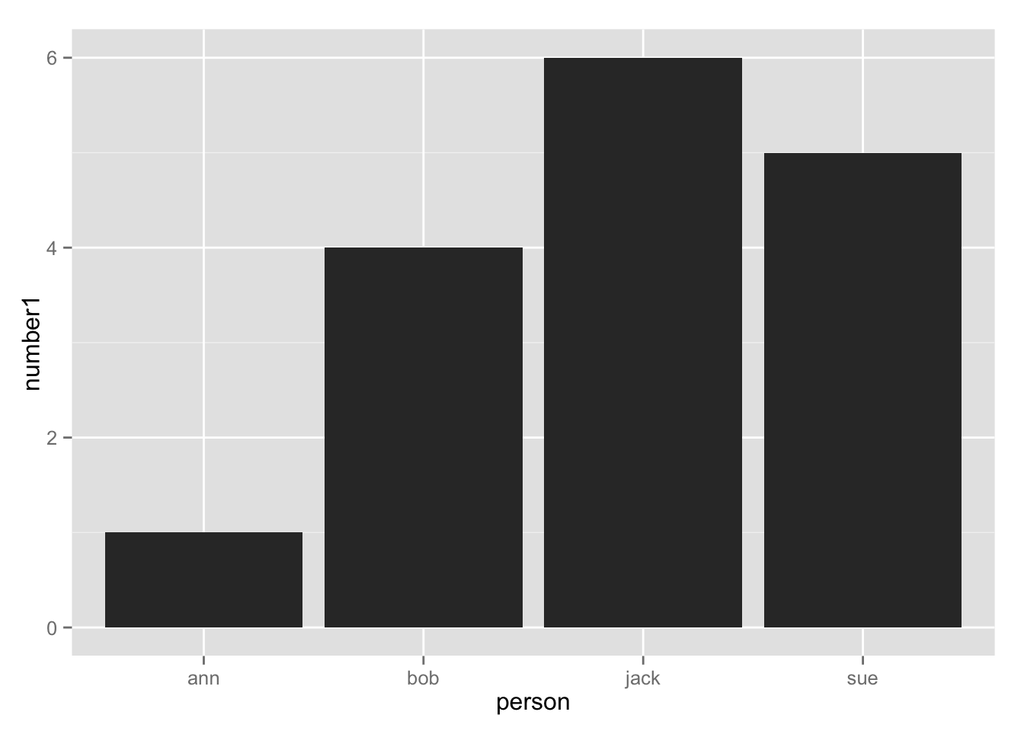

```r
## formatting for barcharts
ggplot(df1, aes(x = person, y = number1)) +
     geom_bar(stat = "identity")
```

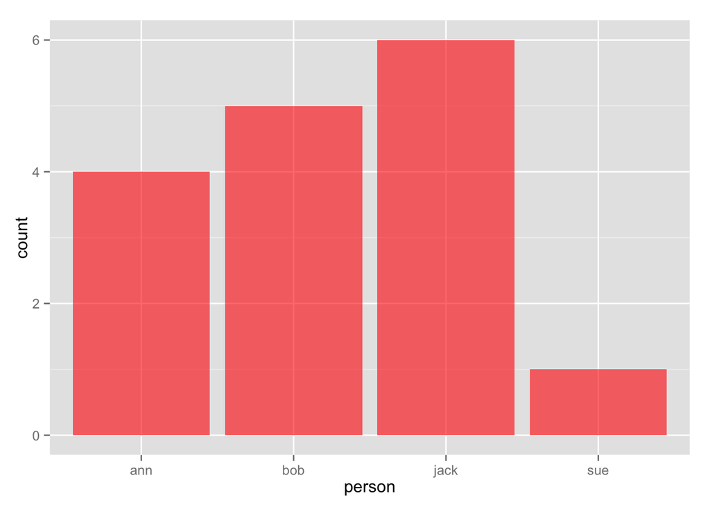

```r
## or reshape the data frame
df.long <- data.frame(person = unlist(sapply(df1$person,
                                             FUN = function(x)
                                                  rep(x, times = df1[x, "number1"]))))

ggplot(df.long, aes(x = person)) +
     geom_bar( fill = "red", alpha = 0.6)
```

## Loops

```r
# for loops repeat a specific number of times
for(i in 1:10){
     print(i + 100)
}
```

```
## [1] 101
## [1] 102
## [1] 103
## [1] 104
## [1] 105
## [1] 106
## [1] 107
## [1] 108
## [1] 109
## [1] 110
```

```r
for(ii in df1$person){
    print(rep(ii, times = df1[df1$person == ii, "number1"]))
}
```

```
## [1] "bob" "bob" "bob" "bob"
## [1] "sue" "sue" "sue" "sue" "sue"
## [1] "jack" "jack" "jack" "jack" "jack" "jack"
## [1] "ann"
```

```r
## while loops repeat until something happens
x <- 1
while(x < 10){
     print(x + 100)
     x <- x + 1
}
```

```
## [1] 101
## [1] 102
## [1] 103
## [1] 104
## [1] 105
## [1] 106
## [1] 107
## [1] 108
## [1] 109
```

```r
## Apply functions are often faster than loops

# for loop
system.time({

     newVec <- numeric()
     for(ii in 1:50000){
          newVec[ii] <- ii + 100
     }
})
```

```
##    user  system elapsed
##   8.619   5.229  14.795
```

```r
head(newVec)
```

```
## [1] 101 102 103 104 105 106
```

```r
## sapply function
system.time({
     newVec.sa <- sapply(1:100000, FUN = function(x) x + 100)
})
```

```
##    user  system elapsed
##   0.149   0.004   0.173
```

```r
## you can speed up a for-loop by pre-allocating space
system.time({

     newVec <- numeric(100000)
     for(ii in 1:100000){
          newVec[ii] <- ii + 100
     }
})
```

```
##    user  system elapsed
##   0.188   0.004   0.221
```